# PROJECTClusteringofbikes

Abhinav and Keerthana

2024-05-04

```r
#install.packages("ggstatsplot")
#install.packages("psych")
#install.packages("plotrix")
```

```r
library(caret)
```

```r
library(plotrix)
library(psych)
library(dplyr)
library(ggstatsplot)
library(cluster)
library(factoextra)
library(FactoMineR)
df <- read.csv("Bikes_dataset.csv")
str(df)
```

```
## 'data.frame':    10000 obs. of  9 variables:
##  $ Brand             : chr  "acabion" "acabion" "acabion" "acabion" ...
##  $ Engine.cylinder   : chr  "Electric" "Single cylinder" "Electric" "Electric" ...
##  $ Category          : chr  "Naked bike" "Sport" "Naked bike" "Naked bike" ...
##  $ Displacement..ccm.: num  125 125 125 125 125 125 125 125 125 125 ...
##  $ Power..hp.        : num  15 15 15 15 15 15 15 15 15 15 ...
##  $ Torque..Nm.       : num  11.8 11.8 11.8 11.8 11.8 11.8 11.8 11.8 11.8 11.8 ...
##  $ Wheelbase..mm.    : int  NA NA 1520 1520 1369 1369 NA NA NA NA ...
##  $ Seat.height..mm.  : int  805 805 805 805 NA NA NA 784 784 795 ...
##  $ Gearbox           : int  NA 6 NA NA 6 7 7 7 7 7 ...
```

```r
summary(df)
```

```
##     Brand           Engine.cylinder      Category         Displacement..ccm.
##  Length:10000       Length:10000       Length:10000       Min.   : 125.0
##  Class :character   Class :character   Class :character   1st Qu.: 180.0
##  Mode  :character   Mode  :character   Mode  :character   Median : 249.0
##                                                           Mean   : 259.9
##                                                           3rd Qu.: 299.3
##                                                           Max.   :1868.0
##
##    Power..hp.      Torque..Nm.    Wheelbase..mm. Seat.height..mm.
##  Min.   :  1.30   Min.   : 3.20   Min.   : 745   Min.   : 39.0
##  1st Qu.: 13.00   1st Qu.:13.00   1st Qu.:1320   1st Qu.:762.0
##  Median : 18.00   Median :19.00   Median :1384   Median :790.0
##  Mean   : 20.91   Mean   :20.15   Mean   :1393   Mean   :810.1
##  3rd Qu.: 27.00   3rd Qu.:25.00   3rd Qu.:1476   3rd Qu.:870.0
##  Max.   :201.00   Max.   :79.00   Max.   :2130   Max.   :998.0
##  NA's   :3588     NA's   :6743    NA's   :3865   NA's   :4378
##     Gearbox
##  Min.   :1.000
##  1st Qu.:5.000
##  Median :6.000
##  Mean   :5.832
##  3rd Qu.:7.000
##  Max.   :8.000
##  NA's   :1817
```

```r
View(df)
```

#Counting the missing values

```r
df <- na.omit(df)
missing_values <- colSums(is.na(df))
missing_values
```

```
##              Brand    Engine.cylinder           Category Displacement..ccm.
##                  0                  0                  0                  0
##         Power..hp.        Torque..Nm.     Wheelbase..mm.   Seat.height..mm.
##                  0                  0                  0                  0
##            Gearbox
##                  0
```

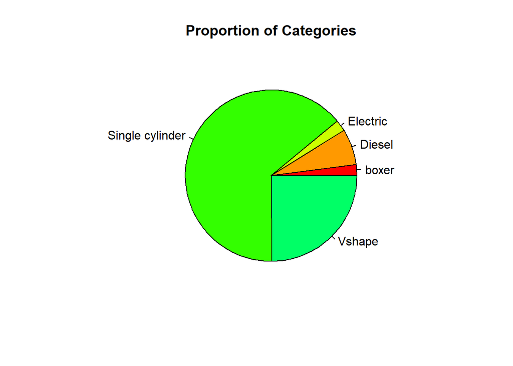

```r
# Create a pie chart
# Create a factor from the 'Engine.cylinder' column
freq_table <- factor(df$Engine.cylinder)

# Create a pie chart with base R
pie(table(df$Engine.cylinder), main = "Proportion of Categories", col = rainbow(10), cex = 1)
```

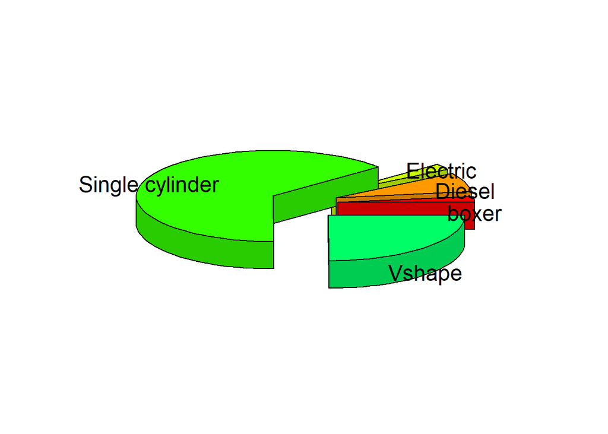

```r
# Create a 3D pie chart with 'pie3D' from the 'plotrix' package
library(plotrix)
pie3D(table(freq_table), labels = levels(freq_table), explode = 0.25, col = rainbow(10))
```

```r
# Calculate and paste the frequencies as percentages
paste(prop.table(table(freq_table)) * 100, "%")
```

```
## [1] "2.10280373831776 %" "6.77570093457944 %" "2.10280373831776 %"
## [4] "64.1355140186916 %" "24.8831775700935 %"
```

#Finding out outliers using boxplot

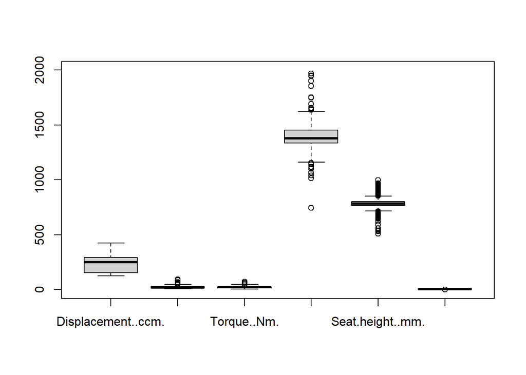

```r
data_df <- df[,4:9]

# Create the boxplot
boxplot(data_df , outline=TRUE, freq = 500, ylim= c(0,2000))
```

```r
summary(data_df)
```

```
##  Displacement..ccm.   Power..hp.     Torque..Nm.    Wheelbase..mm.
##  Min.   :125.0      Min.   : 6.50   Min.   : 3.80   Min.   : 745
##  1st Qu.:155.0      1st Qu.:14.30   1st Qu.:13.80   1st Qu.:1335
##  Median :249.0      Median :20.10   Median :21.00   Median :1380
##  Mean   :245.0      Mean   :22.38   Mean   :20.99   Mean   :1400
##  3rd Qu.:292.4      3rd Qu.:27.50   3rd Qu.:27.00   3rd Qu.:1452
##  Max.   :426.0      Max.   :93.90   Max.   :72.00   Max.   :2100
##  Seat.height..mm.    Gearbox
##  Min.   :508.0    Min.   :1.000
##  1st Qu.:765.0    1st Qu.:5.000
##  Median :785.0    Median :6.000
##  Mean   :786.1    Mean   :5.974
##  3rd Qu.:800.0    3rd Qu.:7.000
##  Max.   :998.0    Max.   :8.000
```

The analysis identified outliers across multiple variables, particularly in power, torque, and wheelbase. The boxplots provided a visual representation of the outliers, while the statistical summary offered numerical insights into the central tendency and spread of each variable.Along with this, we have the statistical summary and data insights from the R console present next to it.

The presence of outliers suggests that some motorcycles in the dataset possess unusually high or low specifications. These outliers could be further investigated or removed based on the study’s objectives. The methodology used in this report demonstrates the value of combining boxplots and summary statistics for exploratory data analysis.

```r
#install.packages("fastDummies")
library(fastDummies)
```

#Creating dummy variables for CATEGORICAL VARIABLES “Engine cylinder”.

```r
Engine_cylinders_dummies <- dummy_cols(df, select_columns = c("Engine.cylinder"))
head(Engine_cylinders_dummies)
```

```
##     Brand Engine.cylinder   Category Displacement..ccm. Power..hp. Torque..Nm.
## 1 acabion Single cylinder        ATV                125       12.1        11.5
## 2 acabion Single cylinder        ATV                125       12.1        11.5
## 3 acabion Single cylinder        ATV                125       14.8        12.0
## 4 acabion Single cylinder        ATV                125       14.8        12.0
## 5 acabion Single cylinder        ATV                125       14.8        12.0
## 6 acabion Single cylinder Naked bike                125        8.3         9.2
##   Wheelbase..mm. Seat.height..mm. Gearbox Engine.cylinder_boxer
## 1           1346              799       7                     0
## 2           1390              799       7                     0
## 3           1390              799       7                     0
## 4           1395              799       7                     0
## 5           1390              799       7                     0
## 6           1276              750       7                     0
##   Engine.cylinder_Diesel Engine.cylinder_Electric
## 1                      0                        0
## 2                      0                        0
## 3                      0                        0
## 4                      0                        0
## 5                      0                        0
## 6                      0                        0
##   Engine.cylinder_Single cylinder Engine.cylinder_Vshape
## 1                               1                      0
## 2                               1                      0
## 3                               1                      0
## 4                               1                      0
## 5                               1                      0
## 6                               1                      0
```

#Creating dummy variables for CATEGORICAL VARIABLES “Brand”.

```r
Brand_dummies <- dummy_cols(df, select_columns = c("Brand"))
head(Brand_dummies)
```

```
##     Brand Engine.cylinder   Category Displacement..ccm. Power..hp. Torque..Nm.
## 1 acabion Single cylinder        ATV                125       12.1        11.5
## 2 acabion Single cylinder        ATV                125       12.1        11.5
## 3 acabion Single cylinder        ATV                125       14.8        12.0
## 4 acabion Single cylinder        ATV                125       14.8        12.0
## 5 acabion Single cylinder        ATV                125       14.8        12.0
## 6 acabion Single cylinder Naked bike                125        8.3         9.2
##   Wheelbase..mm. Seat.height..mm. Gearbox Brand_acabion Brand_benelli Brand_bmw
## 1           1346              799       7             1             0         0
## 2           1390              799       7             1             0         0
## 3           1390              799       7             1             0         0
## 4           1395              799       7             1             0         0
## 5           1390              799       7             1             0         0
## 6           1276              750       7             1             0         0
##   Brand_ducati Brand_harley davidson
## 1            0                     0
## 2            0                     0
## 3            0                     0
## 4            0                     0
## 5            0                     0
## 6            0                     0
```

#Creating dummy variables for CATEGORICAL VARIABLES “Category”.

```r
Category_dummies <- dummy_cols(df, select_columns = c("Category"))
head(Category_dummies)
```

```
##     Brand Engine.cylinder   Category Displacement..ccm. Power..hp. Torque..Nm.
## 1 acabion Single cylinder        ATV                125       12.1        11.5
## 2 acabion Single cylinder        ATV                125       12.1        11.5
## 3 acabion Single cylinder        ATV                125       14.8        12.0
## 4 acabion Single cylinder        ATV                125       14.8        12.0
## 5 acabion Single cylinder        ATV                125       14.8        12.0
## 6 acabion Single cylinder Naked bike                125        8.3         9.2
##   Wheelbase..mm. Seat.height..mm. Gearbox Category_ATV Category_Custom  cruiser
## 1           1346              799       7            1                        0
## 2           1390              799       7            1                        0
## 3           1390              799       7            1                        0
## 4           1395              799       7            1                        0
## 5           1390              799       7            1                        0
## 6           1276              750       7            0                        0
##   Category_Naked bike Category_Sport Category_Touring
## 1                   0              0                0
## 2                   0              0                0
## 3                   0              0                0
## 4                   0              0                0
## 5                   0              0                0
## 6                   1              0                0
```